# Resumen

Laura Gonzalez

2023-03-02

# Aspectos del Analisis Multivariado

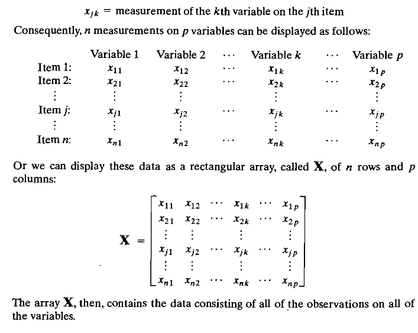

```r
knitr::include_graphics("2.png")
```

```r
library(Matrix)

x1 = c(42,52,48,58);
x2 = c(4,5,4,3);

X <- cbind(x1,x2);X
```

```
##      x1 x2
## [1,] 42  4
## [2,] 52  5
## [3,] 48  4
## [4,] 58  3
```

## Vector de Medias

```r
x_bar <- colMeans(X); x_bar
```

```
## x1 x2
## 50  4
```

## Matriz de varianzas y covarianzas

```r
Sn <- cov(X)*(nrow(X)-1)/nrow(X);Sn
```

```
##      x1   x2
## x1 34.0 -1.5
## x2 -1.5  0.5
```

## Matriz de correlación

```r
R<-cor(X);R
```

```
##            x1         x2
## x1  1.0000000 -0.3638034
## x2 -0.3638034  1.0000000
```

## Distancia de x1 a x2

```r
dist_1 <- function(x1,x2){
  resu = 0;
  for (i in 1:length(x1)){
    resu = resu + (x1[i]-x2[i])^2;
  }
  return(sqrt(resu))
}

dist_1(X[,1],X[,2])
```

```
## [1] 92.81164
```

# Algebra Matricial y vectores aleatrorios

## Transpuesta

Simetrica es lo mismo que transpuesta

```r
x = matrix(c(1,2,3),1,3);x
```

```
##      [,1] [,2] [,3]
## [1,]    1    2    3
```

```r
x_com=t(x);x_com
```

```
##      [,1]
## [1,]    1
## [2,]    2
## [3,]    3
```

## Longitud de x

```r
lengt <- function(x){
  n = length(x);
  value = 0;
  for( i in 1:n){
    value = value + (x[i])^2;
  }
  return(sqrt(value))
}

X = c(1,2,3);
lengt(X)
```

```
## [1] 3.741657
```

## Angulo entre dos vectores

```r
x <- matrix(c(1,3,2),3,1);x
```

```
##      [,1]
## [1,]    1
## [2,]    3
## [3,]    2
```

```r
y <- matrix(c(-2,1,-1),3,1);y
```

```
##      [,1]
## [1,]   -2
## [2,]    1
## [3,]   -1
```

```r
cos_theta <- function(x1,x2){
  return((t(x1)%*%x2)/(lengt(x1)*lengt(x2)))
}
cos_theta(x,y)
```

```
##            [,1]
## [1,] -0.1091089
```

## Vectores Independientes

Revisar si es importantes.

## Proyección de x en y

```r
proy_x_y <- function(x,y){
  return( as.numeric((t(x)%*%y/t(y)%*%y)) * y )
}

proy_x_y(x,y)
```

```
##            [,1]
## [1,]  0.3333333
## [2,] -0.1666667
## [3,]  0.1666667
```

## Inversa de una matriz

```r
A <- rbind(c(2,-2,2),c(2,1,0),c(3,-2,2));A
```

```
##      [,1] [,2] [,3]
## [1,]    2   -2    2
## [2,]    2    1    0
## [3,]    3   -2    2
```

```r
A_inv <- solve(A);A_inv
```

```
##      [,1] [,2] [,3]
## [1,] -1.0    0    1
## [2,]  2.0    1   -2
## [3,]  3.5    1   -3
```

## Matriz definida positiva

Una matriz es definida positiva, Si todos los autovalores son positivos, la matriz es definida positivamente. Si hay autovalores negativos o cero, la matriz no es definida positivamente.

```r
A <- rbind(c(9,-2),c(-2,6));A
```

```
##      [,1] [,2]
## [1,]    9   -2
## [2,]   -2    6
```

```r
eig <- eigen(A);

eig$values
```

```
## [1] 10  5
```

```r
eig$vectors
```

```
##            [,1]       [,2]
## [1,] -0.8944272 -0.4472136
## [2,]  0.4472136 -0.8944272
```

## Descomposición espectral.

```r
des_espectral <- function(A){
  ro = nrow(A);  lambda <- eigen(A);
  n = length(lambda);
  Result = 0;
  for (i in 1:n) {
    print(sprintf("El %d valor propio de la matriz es: %g", i, lambda$values[i]))
    vect_pro <- matrix(c(lambda$vectors[,i]), nrow = ro, ncol = 1);
    print(sprintf("El vector propio es %s.", toString(vect_pro)))
    print(sprintf("Obteniendo la matriz %d :", i))
    Opera = lambda$values[i]*vect_pro%*%t(vect_pro);
    print(Opera)
    Result = Result + Opera;
  }
  print("El resultado de sumar las matrices x' es:")
  print(Result)
  return(Result)
}

Z <- des_espectral(A);
```

```
## [1] "El 1 valor propio de la matriz es: 10"
## [1] "El vector propio es -0.894427190999916, 0.447213595499958."
## [1] "Obteniendo la matriz 1 :"
##      [,1] [,2]
## [1,]    8   -4
## [2,]   -4    2
## [1] "El 2 valor propio de la matriz es: 5"
## [1] "El vector propio es -0.447213595499958, -0.894427190999916."
## [1] "Obteniendo la matriz 2 :"
##      [,1] [,2]
## [1,]    1    2
## [2,]    2    4
## [1] "El resultado de sumar las matrices x' es:"
##      [,1] [,2]
## [1,]    9   -2
## [2,]   -2    6
```

## Matriz raiz cuadrada

```r
A <- rbind(c(2,1),c(1,3));A
```

```
##      [,1] [,2]
## [1,]    2    1
## [2,]    1    3
```

```r
root_square <- function(A){
  eig <- eigen(A);
  x  = (eig$vectors) %*% sqrt(diag(as.vector(eig$values)))  %*% t(eig$vectors);
  return(x)

}

ra_A <- root_square(A);ra_A
```

```
##           [,1]      [,2]
## [1,] 1.3763819 0.3249197
## [2,] 0.3249197 1.7013016
```

```r
in_ra_a <- solve(ra_A); in_ra_a
```

```
##            [,1]       [,2]
## [1,]  0.7608452 -0.1453085
## [2,] -0.1453085  0.6155367
```

```r
round(root_square(A) %*% solve(ra_A))
```

```
##      [,1] [,2]
## [1,]    1    0
## [2,]    0    1
```

# Geometria de la muestra y muestras aleatorias

## Descomposición en las componentes de desviación

```r
dd_dot <- function(x,y){
  return(x%*%y)
}

x <- cbind(c(4,-1,3),c(1,3,5));x
```

```
##      [,1] [,2]
## [1,]    4    1
## [2,]   -1    3
## [3,]    3    5
```

```r
means <- colMeans(x);means
```

```
## [1] 2 3
```

```r
x_t = t(x);
d1 = x_t[1,] - means[1]*c(1,1,1);
d2 = x_t[2,] - means[2]*c(1,1,1);
```

Relacione estas cantidades con $S_n$ y $R$.

Note que $d_x'dy = n \cdot s_{xy}$, donde $n$ es la dimensionalidad de las variables. Por lo cuál al realizar todas las conbinaciones posibles de la matriz $n \times n$ y dividirlas por la $n$-dimensionalidad, se obtentra la misma matriz de varianzas y covarianzas.

```r
dd11 = dd_dot(d1,d1);
dd12 = dd_dot(d1,d2);
dd21 = dd_dot(d2,d1);
dd22 = dd_dot(d2,d2);
s11 =  dd11/3;
s12 =  dd12/3;
s21 =  dd21/3;
s22 =  dd22/3;
vars <- rbind(c(s11,s12),c(s21,s22));vars
```

```
##            [,1]       [,2]
## [1,]  4.6666667 -0.6666667
## [2,] -0.6666667  2.6666667
```

Note que esta matriz es la misma que la matriz de varianzas y covarianzas.

```r
Sn = ((nrow(x)-1)/nrow(x)) * cov(x)
```

```r
r11 =  s11/(sqrt(s11)*sqrt(s11));
r12 =  s12/(sqrt(s11)*sqrt(s22));
r21 =  s21/(sqrt(s22)*sqrt(s11));
r22 =  s22/(sqrt(s22)*sqrt(s22));
vars <- rbind(c(r11,r12),c(r21,r22));vars
```

```
##            [,1]       [,2]
## [1,]  1.0000000 -0.1889822
## [2,] -0.1889822  1.0000000
```

Note que esta matriz es la misma que la matriz de correlación.

```r
cor(x)
```

```
##            [,1]       [,2]
## [1,]  1.0000000 -0.1889822
## [2,] -0.1889822  1.0000000
```

## Varianza Generalizada

La varianza de la muestra se define como:

```r
X <- rbind(c(-1,3,-2),c(2,4,2),c(5,2,3)); X
```

```
##      [,1] [,2] [,3]
## [1,]   -1    3   -2
## [2,]    2    4    2
## [3,]    5    2    3
```

```r
S = var(X) ; S
```

```
##      [,1] [,2] [,3]
## [1,]  9.0 -1.5  7.5
## [2,] -1.5  1.0 -0.5
## [3,]  7.5 -0.5  7.0
```

```r
round(det(S))
```

```
## [1] 0
```

## Varianza Generalizada Determinada por |R|

La multiplicacion de sii*sjj*…*snn (|R|) = |S|

```r
x1 = c(42,52,48,58);
x2 = c(4,5,4,3);
X <- cbind(x1,x2);X
```

```
##      x1 x2
## [1,] 42  4
## [2,] 52  5
## [3,] 48  4
## [4,] 58  3
```

```r
S = var(X) ; S
```

```
##          x1         x2
## x1 45.33333 -2.0000000
## x2 -2.00000  0.6666667
```

```r
det(S)
```

```
## [1] 26.22222
```

```r
R <-cor(X); R
```

```
##            x1         x2
## x1  1.0000000 -0.3638034
## x2 -0.3638034  1.0000000
```

```r
det_R = det(R); det_R
```

```
## [1] 0.8676471
```

```r
det_S = 1;
for (i in 1:ncol(X)){
  det_S = det_S*S[i,i];
}

det_S = det_S * det(R); det_S
```

```
## [1] 26.22222
```

# La Distribución Normal Multivariada.

## Evaluando la Normalidad de una Distribución Univariada Marginal

Diagramas de puntos para n<=25. Histogramas para n>25.

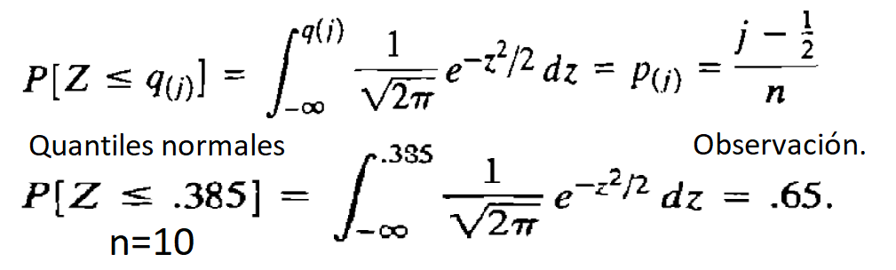

```r
knitr::include_graphics("Uno.png")
```

# Pruebas de Hipotenusa

## Estimador de maxima verosimilitud

Para encontrar los estimadores de máxima verosimilitud de una población normal bivariada a partir de una muestra aleatoria X, necesitamos estimar la media y la matriz de covarianza de la distribución.

La función de densidad de probabilidad para una población normal bivariada con media $\boldsymbol{\mu} = (\mu_1, \mu_2)$ y matriz de covarianza $\boldsymbol{\Sigma}$ es:

$$f(\mathbf{x}; \boldsymbol{\mu},
\boldsymbol{\Sigma}) =
\frac{1}{2\pi|\boldsymbol{\Sigma}|^{1/2}}\exp\left(-\frac{1}{2}(\mathbf{x}-\boldsymbol{\mu})^\mathrm{T}\boldsymbol{\Sigma}^{-1}(\mathbf{x}-\boldsymbol{\mu})\right)$$

Donde $\mathbf{x} = (x_1, x_2)$ es una variable aleatoria bivariada.

Para encontrar los estimadores de máxima verosimilitud de $\boldsymbol{\mu}$ y $\boldsymbol{\Sigma}$ a partir de la muestra X, primero necesitamos calcular la función de verosimilitud. La función de verosimilitud para una muestra aleatoria bivariada es:

$$L(\boldsymbol{\mu}, \boldsymbol{\Sigma};
\mathbf{x}_1, \dots, \mathbf{x}_n) = \prod_{i=1}^n f(\mathbf{x}_i;
\boldsymbol{\mu}, \boldsymbol{\Sigma})$$

Tomando el logaritmo de la función de verosimilitud, obtenemos:

$$\log L(\boldsymbol{\mu},
\boldsymbol{\Sigma}; \mathbf{x}_1, \dots, \mathbf{x}_n) =
-\frac{n}{2}\log(2\pi) -\frac{1}{2}\sum_{i=1}^n\log|\boldsymbol{\Sigma}|
-\frac{1}{2}\sum_{i=1}^n(\mathbf{x}_i-\boldsymbol{\mu})^\mathrm{T}\boldsymbol{\Sigma}^{-1}(\mathbf{x}_i-\boldsymbol{\mu})$$

Podemos encontrar los estimadores de máxima verosimilitud para $\boldsymbol{\mu}$ y $\boldsymbol{\Sigma}$ maximizando esta función de log-verosimilitud.

Para estimar $\boldsymbol{\mu}$, necesitamos maximizar la función de log-verosimilitud con respecto a $\boldsymbol{\mu}$. Tomando la derivada de la función de log-verosimilitud con respecto a $\boldsymbol{\mu}$ e igualando a cero, obtenemos:

$$\hat{\boldsymbol{\mu}} =
\frac{1}{n}\sum_{i=1}^n\mathbf{x}_i$$

Este es el estimador de máxima verosimilitud para la media de la población.

Continuando con la derivación, después de algunas manipulaciones matemáticas, podemos obtener la expresión para el estimador de máxima verosimilitud de $\boldsymbol{\Sigma}$:

$$\hat{\boldsymbol{\Sigma}} =
\frac{1}{n}\sum_{i=1}^n(\mathbf{x}_i-\hat{\boldsymbol{\mu}})(\mathbf{x}_i-\hat{\boldsymbol{\mu}})^\mathrm{T}$$

Este es el estimador de máxima verosimilitud para la matriz de covarianza de la población.

Para calcular estos estimadores en R, podemos utilizar las siguientes líneas de código:

```r
### Likehood con muestra
X = matrix(c(3, 4, 5, 4, 6, 4, 7, 7), ncol=2);
n = nrow(X);
mu_hat = colMeans(X);
Sigma_hat = cov(X); Sigma_hat
```

```
##           [,1]      [,2]
## [1,] 0.6666667 0.3333333
## [2,] 0.3333333 2.0000000
```

## T2 la distribución que no es T-student.

```r
X = cbind(c(2,8,6,8), c(12,9,9,10));X
```

```
##      [,1] [,2]
## [1,]    2   12
## [2,]    8    9
## [3,]    6    9
## [4,]    8   10
```

```r
mu_0 = c(7,11);mu_0
```

```
## [1]  7 11
```

```r
T2 = function (X, mu_0) { # Esto es la T^2
  x_bar = colMeans(X);
  S = cov(X);

  n = nrow(X);
  return(n * t(x_bar - mu_0) %*% solve(S) %*% (x_bar - mu_0));
}

F_val = function (X, mu_0, alpha = 0.05) { # Esto es fisher
  p = length(mu_0);
  n = nrow(X)

  df_num = p;
  df_denom = n - p;

  return(qf(1 - alpha, df_num, df_denom));
}


T2_F = function(X, mu_0, alpha = 0.05) { # Una vaiana rara que utiliza fisher y maso la T^2
  p = length(mu_0);
  n = nrow(X);

  df_num = (n - 1) * p;
  df_denom = n - p;
  return(df_num / df_denom * F_val(X, mu_0, alpha));
}

# ACA SE CAMBIA EL ALPHAAAAAA
T2_test = function(X, mu_0, alpha = 0.05) { # T2 debe ser menor que T2_F para aceptar
  return(T2(X, mu_0) < T2_F(X, mu_0, alpha)); # Si retorna true, se acepta mu_0.
}


T2_test(X, mu_0)
```

```
##      [,1]
## [1,] TRUE
```

## Wili Wonkas Lambda

```r
# Preferir este. Este es solo Lambda
wilks_lambda_1 = function(X, mu_0) {
  n = nrow(X);
  p = length(mu_0);
  x_bar = colMeans(X);

  S = matrix(0, ncol = p, nrow = p);
  for (i in 1:n) {
    si = X[i, ] - x_bar;
    S = S + si %*% t(si);
  }

  B = matrix(0, ncol = p, nrow = p);
  for (i in 1:n) {
    bi = X[i, ] - mu_0;
    B = B + bi %*% t(bi);
  }

  W = det(S) / det(B);

  return(W ^ (n / 2)) # Dividir por 4 si necesitan lambda^(1/2) para la prueba
}

# Este es Lambda ^(2/n)
wilks_lambda_2 = function(X, mu_0) {
  t2 = T2(X, mu_0);
  n = nrow(X);

  return((1 + t2 / (n - 1)) ^ -1)
}

X = cbind(c(2,8,6,8), c(12,9,9,10));X
```

```
##      [,1] [,2]
## [1,]    2   12
## [2,]    8    9
## [3,]    6    9
## [4,]    8   10
```

```r
mu_0 = c(7,11);mu_0
```

```
## [1]  7 11
```

```r
wilks_lambda_1(X,mu_0)
```

```
## [1] 0.03251814
```

```r
wilks_lambda_1(X,mu_0)^(2/nrow(X))
```

```
## [1] 0.1803279
```

```r
lams = wilks_lambda_2(X, mu_0); lams
```

```
##           [,1]
## [1,] 0.1803279
```

```r
# Reemplazar este lambda por el alfa y comparar lo que da

T2_test(X, mu_0)
```

```
##      [,1]
## [1,] TRUE
```

```r
T2_test(X, mu_0,lams)
```

```
##       [,1]
## [1,] FALSE
```

## Ejes de Confianza - Major Axses

```r
Z = cars;
h0 = c(16,40);

sqrt_axes <-function(Z,ho,i){
  p = length(h0);
  n = nrow(Z);
  einz = eigen(cov(Z));
  return(sqrt(einz$values[i])*sqrt(((p*(n-1))/(n*(n-p)))*F_val(Z,h0)))
}

major_axes <- function(Z,h0){
  p = length(h0);
  n = nrow(Z);
  Z_bar = colMeans(Z);
  einz = eigen(cov(Z));
  z1 = Z_bar + sqrt_axes(Z,h0,1) *einz$vectors[1];
  z2 =  Z_bar - sqrt_axes(Z,h0,1)*einz$vectors[1];
  return(c(z1,z2));
}

minor_axes <- function(Z,h0){
  p = length(h0);
  n = nrow(Z);
  Z_bar = colMeans(Z);
  einz = eigen(cov(Z));
  z1 = Z_bar + sqrt_axes(Z,h0,2)*einz$vectors[2];
  z2 =  Z_bar - sqrt_axes(Z,h0,2)*einz$vectors[2];
  return(c(z1,z2));
}

major_axes(Z,h0)
```

```
##    speed     dist    speed     dist
## 16.96206 44.54206 13.83794 41.41794
```

```r
minor_axes(Z,h0)
```

```
##    speed     dist    speed     dist
## 16.49668 44.07668 14.30332 41.88332
```

## Longitudes

```r
long_axes <-function(X,h0){
  einz = eigen(cov(X));
  n = nrow(Z);
  l1 = sqrt(einz$values[1])*sqrt((1/n)*F_val(Z,h0));
  l2 = sqrt(einz$values[2])*sqrt((1/n)*F_val(Z,h0));
  return(c(l1,l2))
}
long_axes(Z,h0)
```

```
## [1] 6.5996395 0.7782676
```

# Graficar la elipse:

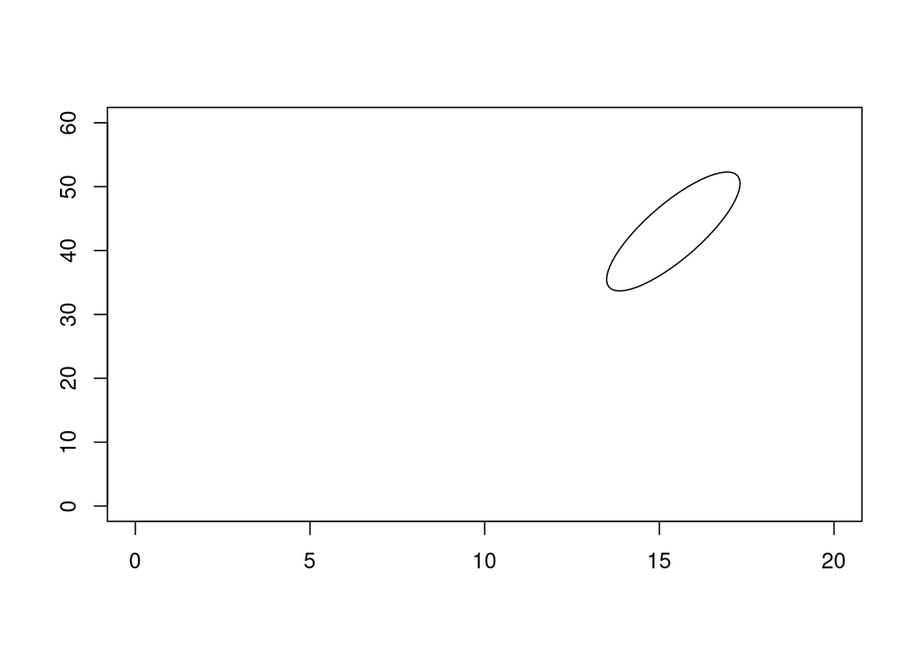

```r
library(plotrix)

# Modificar xlim y ylim para que la figura encaje.

make_hip <- function(Z,ho){
  p = length(h0);
  n = nrow(Z);
  angle = atan(eigen(cov(Z))$vectors[2,1]/eigen(cov(Z))$vectors[1,1])
  plot(0,pch='',ylab='',xlab='',xlim=c(0,20),ylim=c(0,60))
  draw.ellipse(x=colMeans(Z)[1],y=colMeans(Z)[2],a=sqrt_axes(Z,ho,1),b=sqrt_axes(Z,h0,2),angle=angle,deg=FALSE)

}

make_hip(Z,h0)
```

# Graficas

### Graficar en $R^3$ (Plot3D)

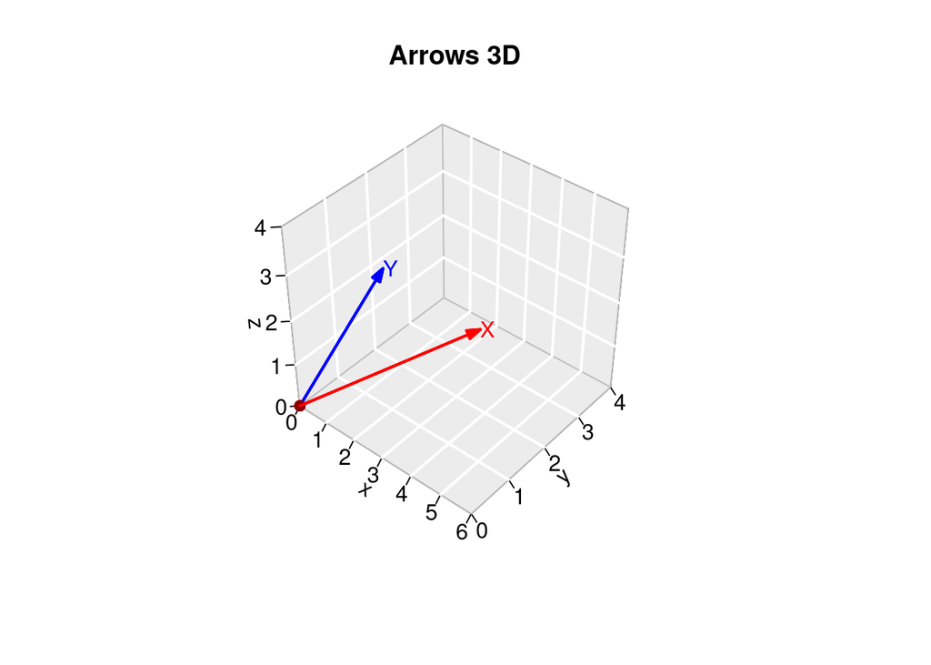

```r
library(plot3D)
x <- c(5, 1, 3)
y <- c(-1, 3, 1)
origin <- c(0,0,0)

x0 = c(0, 0)
y0 = c(0, 0)
z0 = c(0, 0)
cols <- c('red','blue')

x1 = c(5, -1)
y1 = c(1, 3)
z1 = c(3, 1)

arrows3D(x0, y0, z0, x1, y1, z1,  col = cols, lwd = 2, d = 5,
         main = "Arrows 3D", bty ="g", ticktype = "detailed", xlim = c(0,6),
         ylim = c(0,4), zlim = c(0,4))
points3D(x0, y0, z0, add = TRUE, col="darkred",
         colkey = FALSE, pch = 19, cex = 1)
text3D(x1, y1, z1, c("X", "Y"), colvar = NULL, col = cols, add=TRUE, colkey = FALSE)
```

### Boxplot

`boxplot(olive$oleic ~ olive$region, xlab = "Region", ylab = "Oleic")`

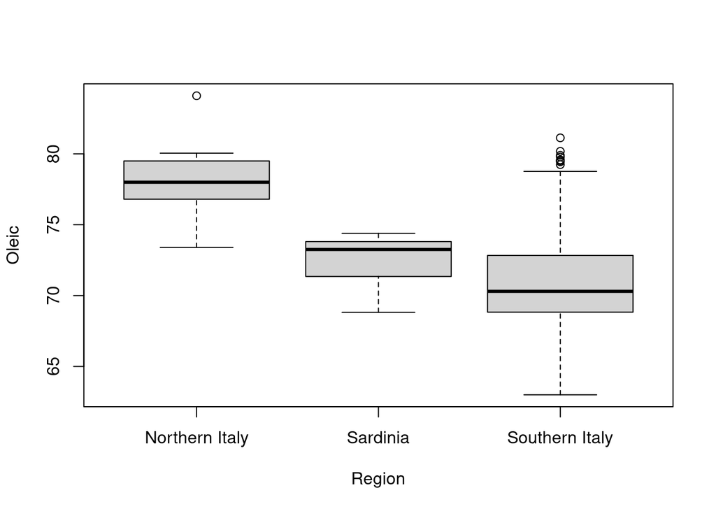

```r
packages = c("dslabs", "MASS", "scatterplot3d", "car")
## Se cargan o se instalan y cargan
package.check <- lapply(
  packages,
  FUN = function(x) {
    if (!require(x, character.only = TRUE)) {
      install.packages(x, dependencies = TRUE)
      library(x, character.only = TRUE)
    }
  }
)
boxplot(olive$oleic ~ olive$region, xlab = "Region", ylab = "Oleic")
```

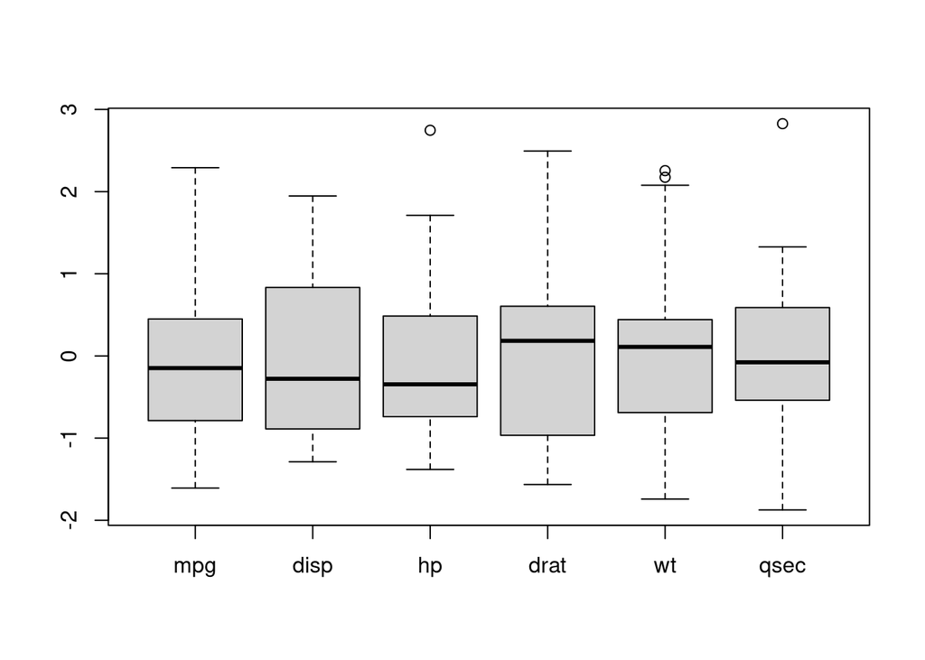

```r
a = mtcars;
a_num = subset(a, select = c(-cyl, -vs, -am, -gear, -carb));
a_num_norm = as.data.frame(scale(a_num));
boxplot(a_num_norm)
```

### Histograma

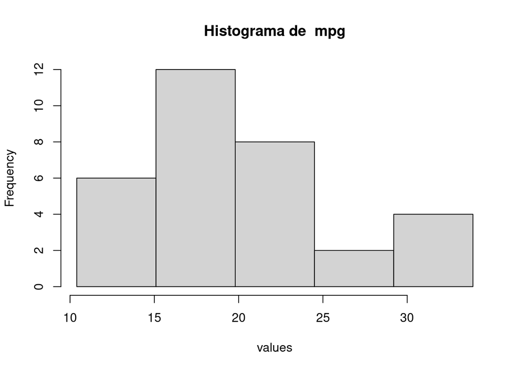

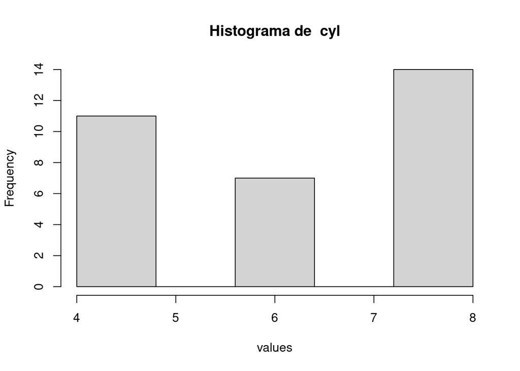

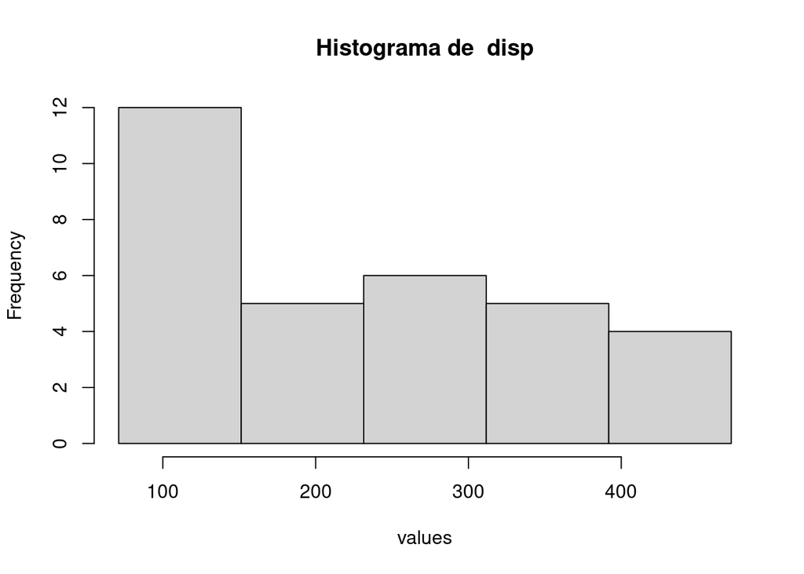

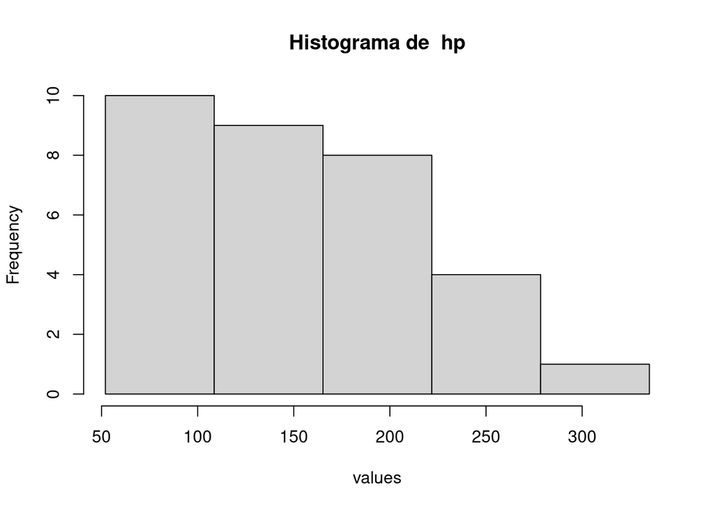

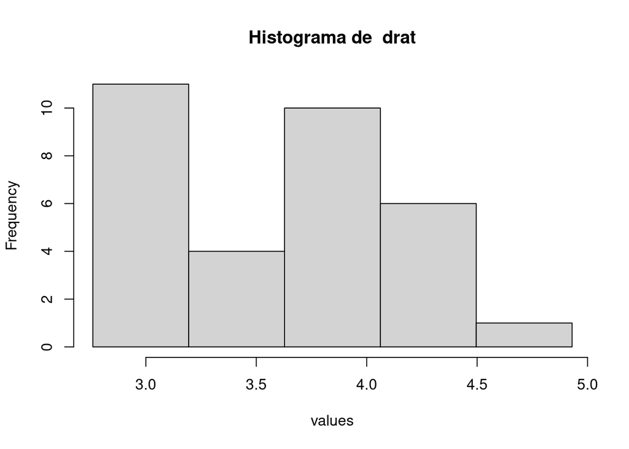

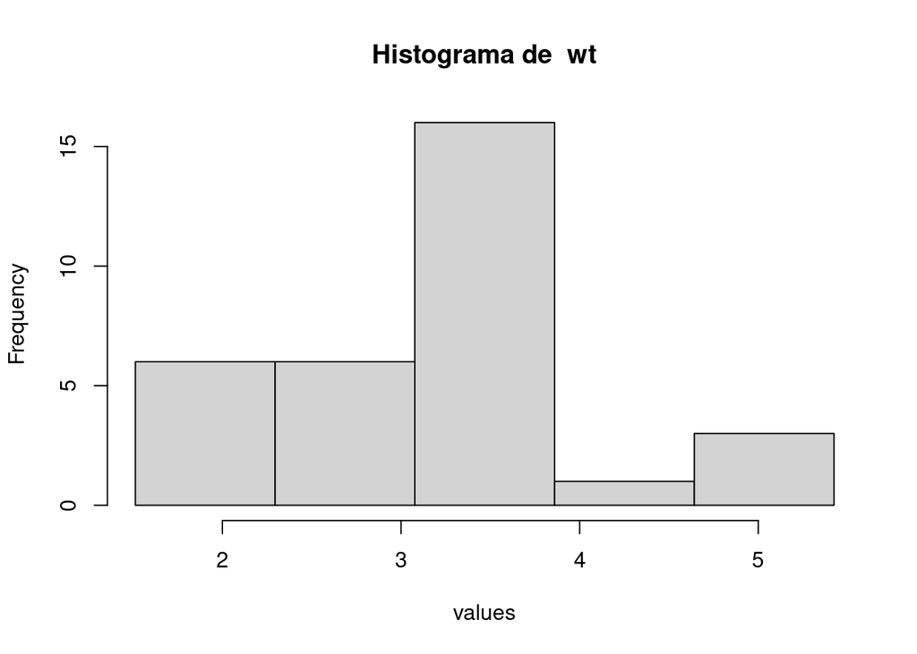

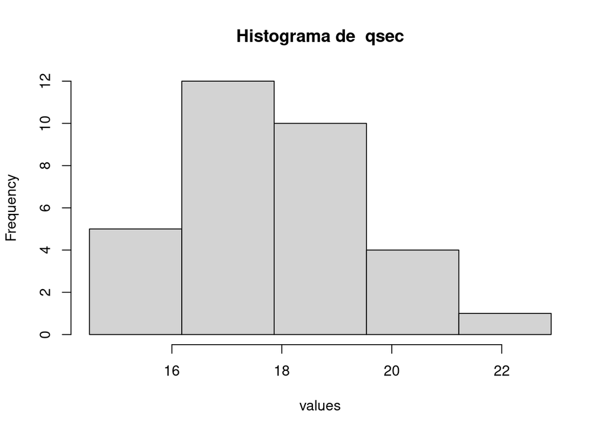

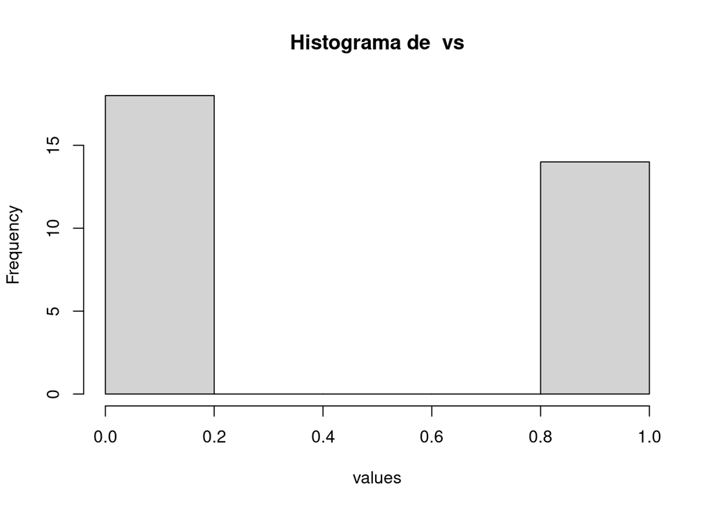

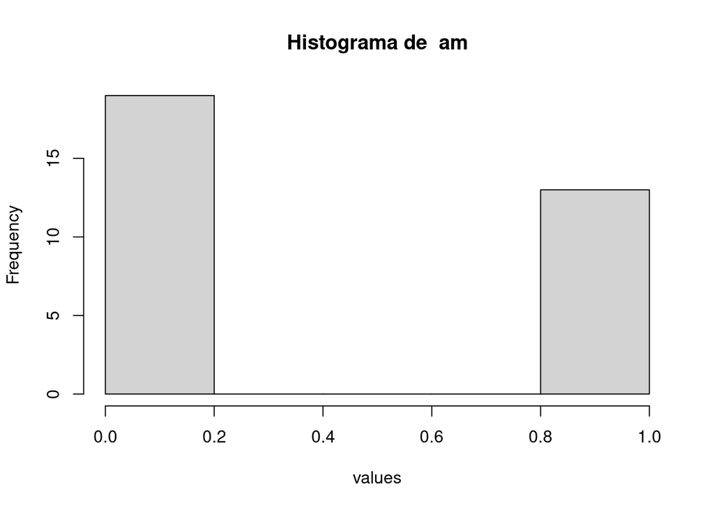

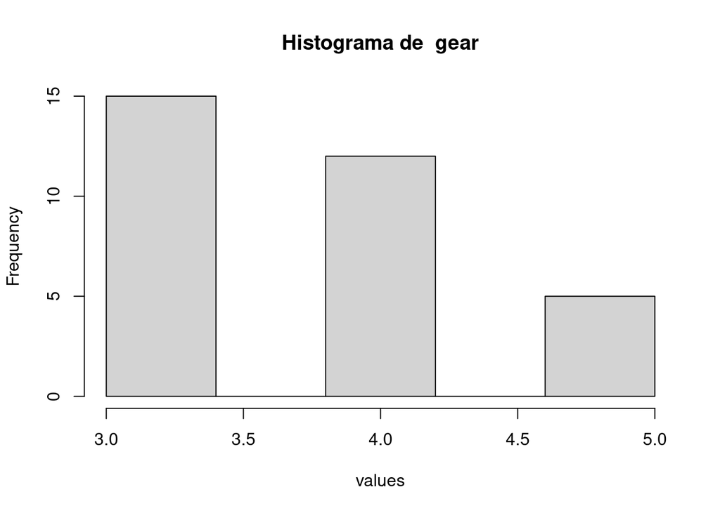

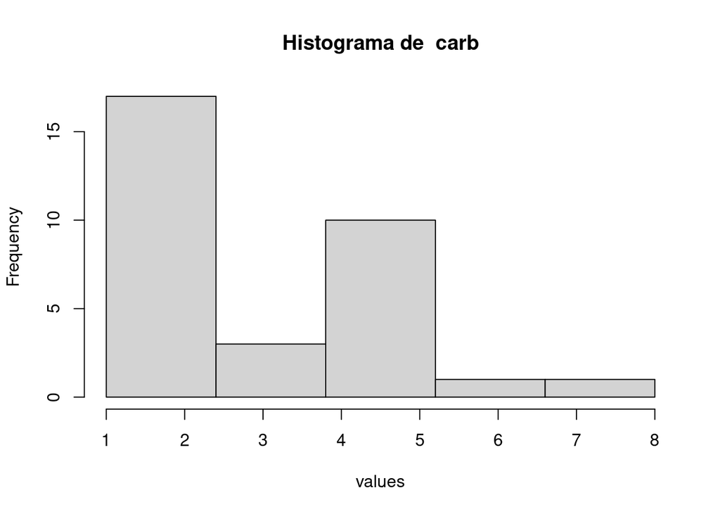

[output not shown]

```r
sapply(colnames(a), function(columna) {
values = unlist(a[columna]);
breaks = seq(min(values), max(values), length.out = 6);
hist(
x = values,
breaks = breaks,
main = paste("Histograma de ", columna)
);
})
```

### Scatterplot

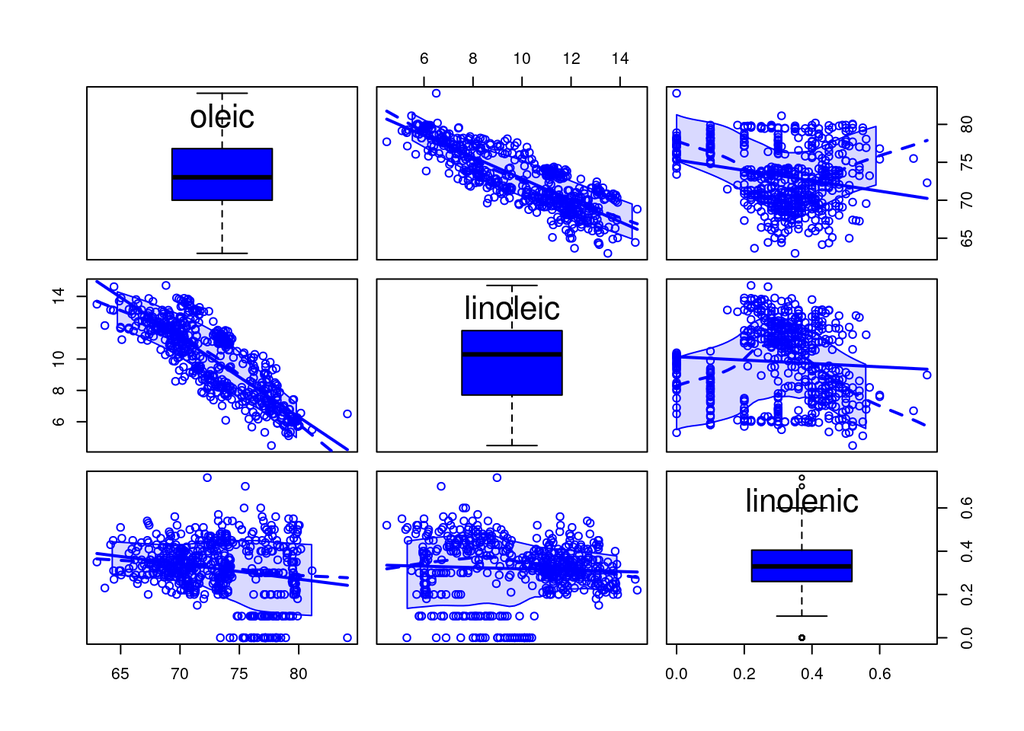

```r
olive_subset = subset(olive, select = c(oleic, linoleic, linolenic))
scatterplotMatrix(~ +., data = olive_subset, diagonal = list(method = "boxplot"))
```

Fin.